# Support Vector Machine based on Tidymodels

Machine Learning

R code using Tidymodels Package for Support Vector Machine

Yeongeun Jeon , Jung In Seo  
04-23-2022

# **0. Schematic Diagram**

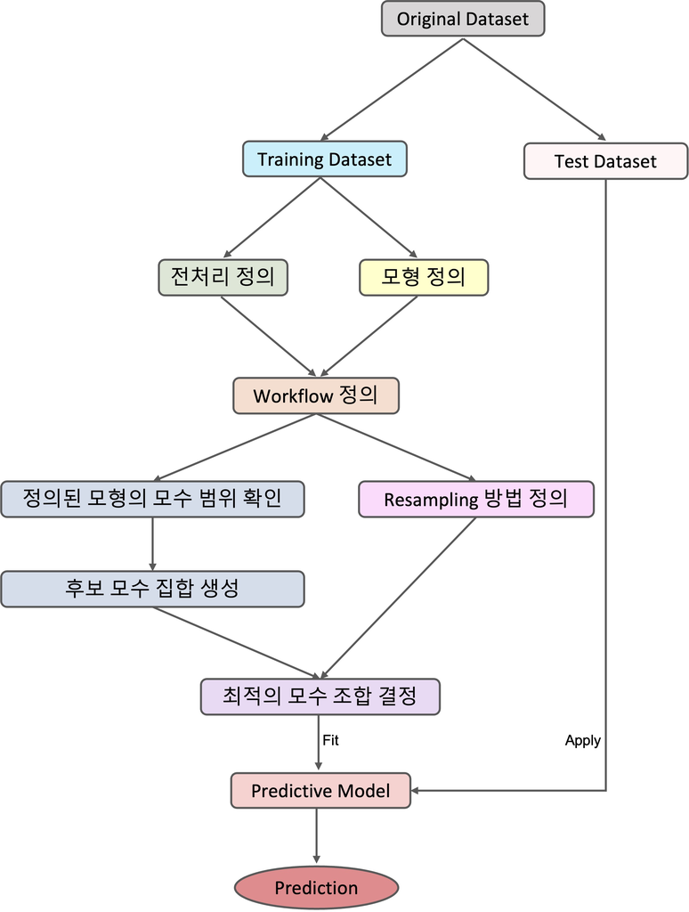

# **1. 데이터 불러오기**

```
# install.packages("tidymodels")
pacman::p_load("MLDataR",                                              # For Data
               "data.table", "magrittr",
               "tidymodels",
               "doParallel", "parallel")

registerDoParallel(cores=detectCores())


data(heartdisease)
data <- heartdisease %>%
  mutate(HeartDisease = ifelse(HeartDisease==0, "no", "yes"))


cols <- c("Sex", "RestingECG", "Angina", "HeartDisease")

data   <- data %>%
  mutate_at(cols, as.factor)                                           # 범주형 변수 변환

glimpse(data)                                                          # 데이터 구조
```

```
Rows: 918
Columns: 10
$ Age              <dbl> 40, 49, 37, 48, 54, 39, 45, 54, 37, 48, 37,~
$ Sex              <fct> M, F, M, F, M, M, F, M, M, F, F, M, M, M, F~
$ RestingBP        <dbl> 140, 160, 130, 138, 150, 120, 130, 110, 140~
$ Cholesterol      <dbl> 289, 180, 283, 214, 195, 339, 237, 208, 207~
$ FastingBS        <dbl> 0, 0, 0, 0, 0, 0, 0, 0, 0, 0, 0, 0, 0, 0, 0~
$ RestingECG       <fct> Normal, Normal, ST, Normal, Normal, Normal,~
$ MaxHR            <dbl> 172, 156, 98, 108, 122, 170, 170, 142, 130,~
$ Angina           <fct> N, N, N, Y, N, N, N, N, Y, N, N, Y, N, Y, N~
$ HeartPeakReading <dbl> 0.0, 1.0, 0.0, 1.5, 0.0, 0.0, 0.0, 0.0, 1.5~
$ HeartDisease     <fct> no, yes, no, yes, no, no, no, no, yes, no, ~
```

# **2. 데이터 분할**

```
set.seed(100)                                                          # seed 고정
data.split <- initial_split(data, prop = 0.7, strata = HeartDisease)   # Partition (Traning Data : Test Data = 7:3)/ initial_split(, strata = 층화추출할 변수)NAHD.train   <- training(data.split)
HD.test    <- testing(data.split)
```

# **3. Linear Kernel**

## **3-1. 전처리 정의**

- `Workflow`를 이용하기 위해 먼저 전처리를 정의한다.

```
rec  <- recipe(HeartDisease ~ ., data = HD.train) %>%                  # recipe(formula, data)
  step_normalize(all_numeric_predictors()) %>%                         # 모든 수치형 예측변수들을 표준화  step_dummy(all_nominal_predictors(), one_hot = TRUE)                 # 모든 범주형 예측변수들에 대해 원-핫 인코딩 더미변수 생성NA
```

## **3-2. 모형 정의**

- 모형을 구축하기 위해 모형을 먼저 정의한다.
  - 모형을 정의하기 위해 `모형 타입(Type)`과 `모형 종류(set_mode)` 그리고 `사용할 패키지(set_engine)`가 필요하다.
    - 모형 타입 : 사용하고자하는 머신러닝 함수 정의
      - Linear Kernel은 함수 `svm_linear()`를 사용한다.
    - 모형 종류 : Target 유형 정의
      - 분류(Classification) 또는 회귀(Regresssion) 중 하나를 선택한다.
    - 사용할 패키지 : 사용하고자하는 Package 정의
      - Linear Kernel은 Package `kernlab`와 `LiblineaR`를 사용할 수 있다.
- Linear Kernel의 모수에는 `cost`와 `margin`이 있다.
  - `cost` : 데이터를 잘못 분류하는 선을 긋게 될 경우 지불해야 할 cost
  - `margin` : SVM insensitive loss function의 epsilon (Only for Regression)
- 튜닝하고 싶은 모수는 함수 `tune()`으로 지정한다.

```
svm.li.tune.mod <- svm_linear(cost = tune()) %>%                       # cost : 데이터를 잘못 분류하는 선을 긋게 될 경우 지불해야 할 costNAset_mode("classification") %>%                                       # Target 유형 정의(classification /  regression)NAset_engine("kernlab")                                                # 사용하고자하는 패키지 정의(kernlab /  LiblineaR) NA# 실제 패키지에 어떻게 적용되는지 확인NAsvm.li.tune.mod %>%
  translate()
```

```
Linear Support Vector Machine Specification (classification)

Main Arguments:
  cost = tune()

Computational engine: kernlab

Model fit template:
kernlab::ksvm(x = missing_arg(), data = missing_arg(), C = tune(),
    kernel = "vanilladot", prob.model = TRUE)
```

`Caution!` 함수 `translate()`를 통해 위에서 정의한 “svm.li.tune.mod”가 실제로 Package `kernlab`의 함수 `ksvm()`에 어떻게 적용되는지 확인할 수 있다.

## **3-3. Workflow 정의**

- 앞에서 정의한 전처리와 모형을 이용하여 `Workflow`를 정의한다.

```
svm.li.tune.wflow <- workflow() %>%                                    # Workflow 정의  add_recipe(rec) %>%                                                  # 3-1에서 정의의
  add_model(svm.li.tune.mod)                                           # 3-2에서 정의의
```

## **3-4. 모수 범위 확인**

- 함수 `extract_parameter_set_dials()`를 이용하여 모수들의 정보를 확인할 수 있다.

```
svm.li.param <- extract_parameter_set_dials(svm.li.tune.wflow)
svm.li.param
```

```
Collection of 1 parameters for tuning

 identifier type    object
       cost cost nparam[+]
```

`Result!` `object`열에서 `nparam`은 모수값이 수치형임을 나타낸다. 또한, `cost`의 `object`열이 `nparam[+]`로 해당 모수의 범위가 명확하게 주어졌음을 의미한다.

- 함수 `extract_parameter_dials()`를 이용하여 모수의 범위를 자세히 확인할 수 있다.

```
svm.li.param %>%
  extract_parameter_dials("cost")
```

```
Cost (quantitative)
Transformer:  log-2
Range (transformed scale): [-10, 5]
```

- `cost`의 범위를 수정하고 싶다면 함수 `update()`를 이용한다.

[output not shown]

## **3-5. 모형 적합**

### **3-5-1. Resampling 정의**

- Linear Kernel의 최적의 모수 조합을 찾기 위해 Resampling 방법으로 `K-Fold Cross-Validation`을 사용한다.

```
set.seed(100)
train.fold    <- vfold_cv(HD.train, v = 5)
```

### **3-5-2. 최적의 모수 조합 찾기**

- 최적의 모수 조합을 찾기 위해 `Regular Grid`, `Latin Hypercube`, `Expand Grid`를 사용한다.

#### **3-5-2-1. Regular Grid**

```
set.seed(100)
grid <-  svm.li.param %>%
  grid_regular(levels = 2)
grid
```

```
# A tibble: 2 x 1
       cost
      <dbl>
1  0.000977
2 32
```

`Result!` `cost`에 대해 후보 모수값 2개를 생성하였다.

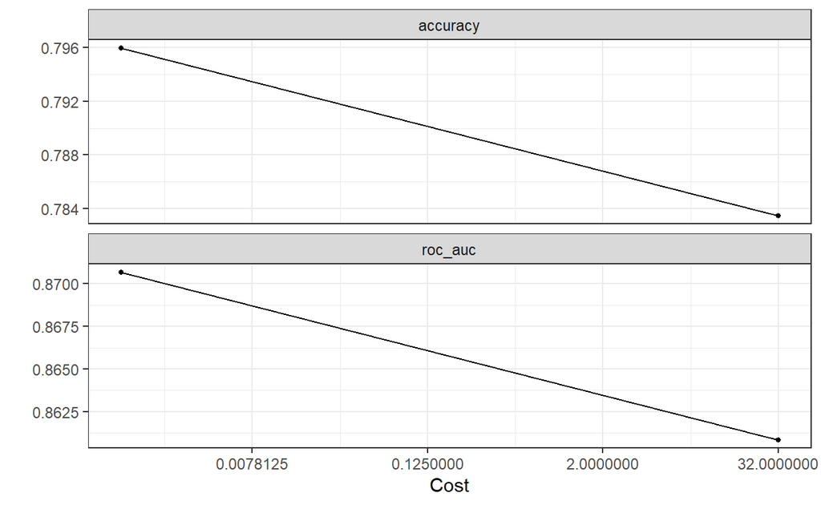

```
# 모형 적합NAset.seed(100)
svm.li.tune.grid.fit <- svm.li.tune.wflow %>%                          # 3-3에서 정의의
  tune_grid(
    train.fold,                                                        # 3-5-1에서 정의 : Resampling -> 5-Cross-Validationn
    grid = grid,                                                       # 3-5-2-1에서 정의 : 후보 모수 집합     control = control_grid(save_pred = TRUE,                           # Resampling의 Assessment 결과 저장NA= "everything"),              # 병렬 처리(http:://tune.tidymodels.org/reference/control_grid.html) )
    metrics = metric_set(roc_auc, accuracy)                            # Assessment 그룹에 대한 Assessment Measure
  )

# 그래프
autoplot(svm.li.tune.grid.fit) +
  scale_color_viridis_d(direction = -1) +
  theme(legend.position = "top") +
  theme_bw()
```

```
# 지정된 Metric 측면에서 성능이 우수한 모형을 순서대로 확인NAshow_best(svm.li.tune.grid.fit, "roc_auc")                             # show_best(, "accuracy")
```

```
# A tibble: 2 x 7
       cost .metric .estimator  mean     n std_err .config
      <dbl> <chr>   <chr>      <dbl> <int>   <dbl> <fct>
1  0.000977 roc_auc binary     0.871     5 0.0123  Preprocessor1_Mode~
2 32        roc_auc binary     0.861     5 0.00919 Preprocessor1_Mode~
```

```
# 최적의 모수 조합 확인NAbest.svm.li.random <- svm.li.tune.grid.fit %>%
  select_best("roc_auc")
best.svm.li.random
```

```
# A tibble: 1 x 2
      cost .config
     <dbl> <fct>
1 0.000977 Preprocessor1_Model1
```

`Result!` `cost = 0.000977`일 때 “ROC AUC” 측면에서 가장 우수한 성능을 보여준다.

#### **3-5-2-2. Latin Hypercube**

```
set.seed(100)
random <- svm.li.param %>%
  grid_latin_hypercube(size = 5)
random
```

```
# A tibble: 5 x 1
      cost
     <dbl>
1  0.00100
2  0.306
3 16.4
4  2.09
5  0.0103
```

`Result!` 후보 모수 5개를 랜덤하게 생성하였다.

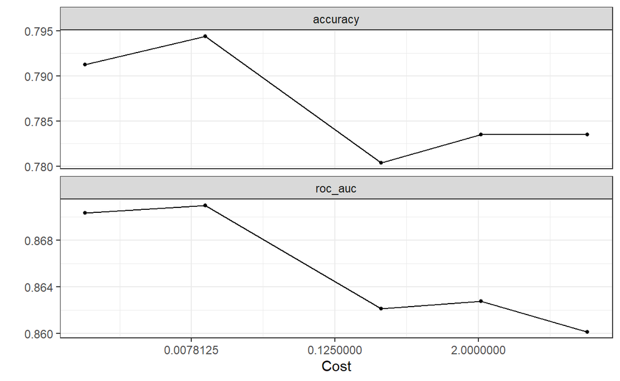

```
# 모형 적합NAset.seed(100)
svm.li.tune.random.fit <- svm.li.tune.wflow %>%                        # 3-3에서 정의의
  tune_grid(
    train.fold,                                                        # 3-5-1에서 정의 : Resampling -> 5-Cross-Validationn
    grid = random,                                                     # 3-5-2-2에서 정의 : 후보 모수 집합     control = control_grid(save_pred = TRUE,                           # Resampling의 Assessment 결과 저장NA= "everything"),              # 병렬 처리(http:://tune.tidymodels.org/reference/control_grid.html) )
    metrics = metric_set(roc_auc, accuracy)                            # Assessment 그룹에 대한 Assessment Measure
  )

# 그래프
autoplot(svm.li.tune.random.fit) +
  scale_color_viridis_d(direction = -1) +
  theme(legend.position = "top") +
  theme_bw()
```

```
# 지정된 Metric 측면에서 성능이 우수한 모형을 순서대로 확인NAshow_best(svm.li.tune.random.fit, "roc_auc")                            # show_best(, "accuracy")
```

```
# A tibble: 5 x 7
      cost .metric .estimator  mean     n std_err .config
     <dbl> <chr>   <chr>      <dbl> <int>   <dbl> <fct>
1  0.0103  roc_auc binary     0.871     5 0.0124  Preprocessor1_Model5
2  0.00100 roc_auc binary     0.870     5 0.0122  Preprocessor1_Model1
3  2.09    roc_auc binary     0.863     5 0.0103  Preprocessor1_Model4
4  0.306   roc_auc binary     0.862     5 0.00916 Preprocessor1_Model2
5 16.4     roc_auc binary     0.860     5 0.00907 Preprocessor1_Model3
```

```
# 최적의 모수 조합 확인NAbest.svm.li.random <- svm.li.tune.random.fit %>%
  select_best("roc_auc")
best.svm.li.random
```

```
# A tibble: 1 x 2
    cost .config
   <dbl> <fct>
1 0.0103 Preprocessor1_Model5
```

`Result!` `cost = 0.0103`일 때 “ROC AUC” 측면에서 가장 우수한 성능을 보여준다.

#### **3-5-2-3. Expand Grid**

- Latin Hypercube 방법에서 최적의 모수인 `cost = 0.0103`을 기준으로 다양한 후보값을 생성한다.

```
egrid <- expand.grid(cost = seq(0.01, 0.011, 0.0001))
egrid
```

```
     cost
1  0.0100
2  0.0101
3  0.0102
4  0.0103
5  0.0104
6  0.0105
7  0.0106
8  0.0107
9  0.0108
10 0.0109
11 0.0110
```

`Result!` 후보 모수값들의 집합이 생성되었다.

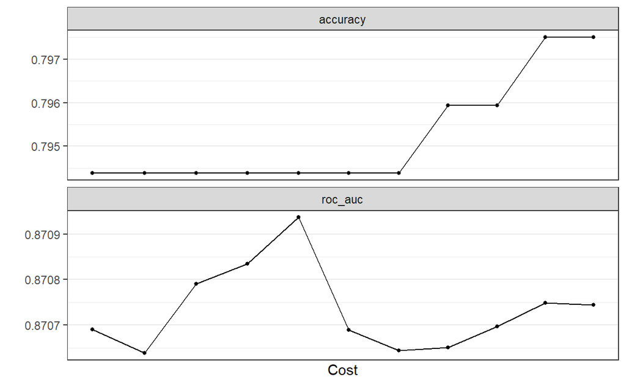

```
# 모형 적합NAset.seed(100)
svm.li.tune.egrid.fit <- svm.li.tune.wflow %>%                          # 3-3에서 정의의
  tune_grid(
    train.fold,                                                         # 3-5-1에서 정의 : Resampling -> 5-Cross-Validationn
    grid = egrid,                                                       # 3-5-2-3에서 정의 : 후보 모수 집합     control = control_grid(save_pred = TRUE,                            # Resampling의 Assessment 결과 저장NA= "everything"),               # 병렬 처리(http:://tune.tidymodels.org/reference/control_grid.html) )
    metrics = metric_set(roc_auc, accuracy)                             # Assessment 그룹에 대한 Assessment Measure
  )

# 그래프
autoplot(svm.li.tune.egrid.fit) +
  scale_color_viridis_d(direction = -1) +
  theme(legend.position = "top") +
  theme_bw()
```

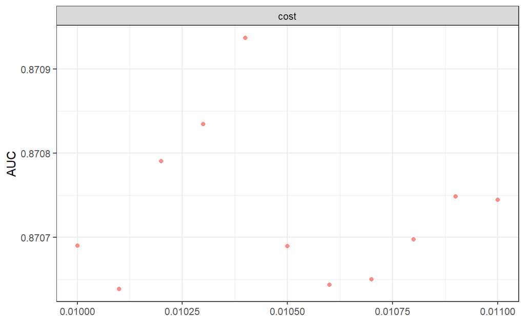

```
# Ref. https://juliasilge.com/blog/svm.lioost-tune-volleyball/
svm.li.tune.egrid.fit %>%
  collect_metrics() %>%
  filter(.metric == "roc_auc") %>%
  select(mean, cost) %>%
  pivot_longer(cost,
               values_to = "value",
               names_to = "parameter"
  ) %>%
  ggplot(aes(value, mean, color = parameter)) +
  geom_point(alpha = 0.8, show.legend = FALSE) +
  facet_wrap(~parameter, scales = "free_x") +
  labs(x = NULL, y = "AUC") +
  theme_bw()
```

```
# 지정된 Metric 측면에서 성능이 우수한 모형을 순서대로 확인NAshow_best(svm.li.tune.egrid.fit, "roc_auc")                                # show_best(, "accuracy")
```

```
# A tibble: 5 x 7
    cost .metric .estimator  mean     n std_err .config
   <dbl> <chr>   <chr>      <dbl> <int>   <dbl> <fct>
1 0.0104 roc_auc binary     0.871     5  0.0124 Preprocessor1_Model05
2 0.0103 roc_auc binary     0.871     5  0.0124 Preprocessor1_Model04
3 0.0102 roc_auc binary     0.871     5  0.0126 Preprocessor1_Model03
4 0.0109 roc_auc binary     0.871     5  0.0124 Preprocessor1_Model10
5 0.011  roc_auc binary     0.871     5  0.0123 Preprocessor1_Model11
```

```
# 최적의 모수 조합 확인NAbest.svm.li.egrid <- svm.li.tune.egrid.fit %>%
  select_best("roc_auc")                                                   # select_best("accuracy")
best.svm.li.egrid
```

```
# A tibble: 1 x 2
    cost .config
   <dbl> <fct>
1 0.0104 Preprocessor1_Model05
```

`Result!` `cost = 0.0104`일 때 “ROC AUC” 측면에서 가장 우수한 성능을 보여준다.

### **3-5-3. 최적의 모수 조합을 이용한 모형 적합**

- 최적의 모수 `cost = 0.0104`을 이용하여 모형을 구축한다.
- 함수 `finalize_workflow()`을 이용하여 앞에서 정의한 “workflow(svm.li.tune.wflow)”를 최적의 모수 조합을 가지는 “workflow”로 업데이트한다.

```
# Workflow에 최적의 모수값 업데이트final.svm.li.wflow <- svm.li.tune.wflow %>%                               # 3-3에서 정의의
  finalize_workflow(best.svm.li.egrid)                                    # finalize_workflow : 최적의 모수 조합을 가지는 workflow로 업데이트NAfinal.svm.li.wflow
```

```
== Workflow ==========================================================
Preprocessor: Recipe
Model: svm_linear()

-- Preprocessor ------------------------------------------------------
2 Recipe Steps

* step_normalize()
* step_dummy()

-- Model -------------------------------------------------------------
Linear Support Vector Machine Specification (classification)

Main Arguments:
  cost = 0.0104

Computational engine: kernlab
```

`Caution!` 함수 `last_fit()`은 최적의 모수 조합에 대해 Training Data를 이용한 모형 적합과 Test Data에 대한 예측을 한 번에 수행할 수 있지만 seed 고정이 되지 않아 Reproducibility (재생산성)가 만족되지 않는다. 따라서, 모형 적합(함수 `fit()`)과 예측(함수 `augment()`)을 각각 수행하였다.

```
# 모형 적합NAset.seed(100)
final.svm.li <- final.svm.li.wflow %>%
  fit(data = HD.train)
final.svm.li
```

```
== Workflow [trained] ================================================
Preprocessor: Recipe
Model: svm_linear()

-- Preprocessor ------------------------------------------------------
2 Recipe Steps

* step_normalize()
* step_dummy()

-- Model -------------------------------------------------------------
Support Vector Machine object of class "ksvm"

SV type: C-svc  (classification)
 parameter : cost C = 0.0104

Linear (vanilla) kernel function.

Number of Support Vectors : 349

Objective Function Value : -3.3389
Training error : 0.191589
Probability model included.
```

```
# 최종 모형NAfinal.svm.li %>%
  extract_fit_engine()
```

```
Support Vector Machine object of class "ksvm"

SV type: C-svc  (classification)
 parameter : cost C = 0.0104

Linear (vanilla) kernel function.

Number of Support Vectors : 349

Objective Function Value : -3.3389
Training error : 0.191589
Probability model included.
```

## **3-6. 예측**

```
svm.li.pred <- augment(final.svm.li, HD.test)
svm.li.pred
```

```
# A tibble: 276 x 13
     Age Sex   RestingBP Cholesterol FastingBS RestingECG MaxHR Angina
   <dbl> <fct>     <dbl>       <dbl>     <dbl> <fct>      <dbl> <fct>
 1    54 M           110         208         0 Normal       142 N
 2    37 M           140         207         0 Normal       130 Y
 3    37 F           130         211         0 Normal       142 N
 4    39 M           120         204         0 Normal       145 N
 5    49 M           140         234         0 Normal       140 Y
 6    42 F           115         211         0 ST           137 N
 7    60 M           100         248         0 Normal       125 N
 8    36 M           120         267         0 Normal       160 N
 9    43 F           100         223         0 Normal       142 N
10    36 M           130         209         0 Normal       178 N
# ... with 266 more rows, and 5 more variables:
#   HeartPeakReading <dbl>, HeartDisease <fct>, .pred_class <fct>,
#   .pred_no <dbl>, .pred_yes <dbl>
```

## **3-7. 모형 평가**

### **3-7-1. 평가 척도**

```
conf_mat(svm.li.pred, truth = HeartDisease, estimate = .pred_class)    # truth : 실제 클래스,  estimate : 예측 클래스 클래스
```

```
          Truth
Prediction  no yes
       no  101  29
       yes  22 124
```

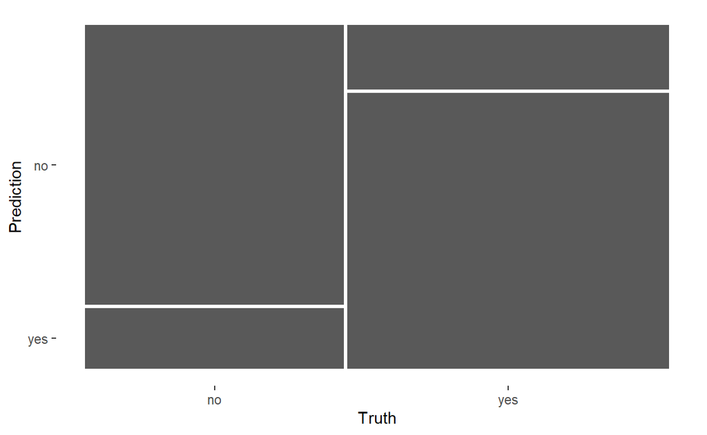

```
conf_mat(svm.li.pred, truth = HeartDisease, estimate = .pred_class) %>%
  autoplot(type = "mosaic")                                            # autoplot(type = "heatmap")
```

```
classification_metrics <- metric_set(accuracy, mcc,
                                     f_meas, kap,
                                     sens, spec, roc_auc)              # Test Data에 대한 Assessment Measure
classification_metrics(svm.li.pred, truth = HeartDisease,              # truth : 실제 클래스,  estimate : 예측 클래스 클래스
                       estimate = .pred_class,
                       .pred_yes, event_level = "second")              # For roc_auc
```

```
# A tibble: 7 x 3
  .metric  .estimator .estimate
  <chr>    <chr>          <dbl>
1 accuracy binary         0.815
2 mcc      binary         0.629
3 f_meas   binary         0.829
4 kap      binary         0.628
5 sens     binary         0.810
6 spec     binary         0.821
7 roc_auc  binary         0.883
```

`Caution!` “ROC AUC”를 계산하기 위해서는 관심 클래스에 대한 예측 확률이 필요하다. 예제 데이터에서 관심 클래스는 “yes”이므로 “yes”에 대한 예측 확률 결과인 `.pred_yes`가 사용되었다. 또한, Target인 “HeartDisease” 변수의 유형을 “Factor” 변환하면 알파벳순으로 클래스를 부여하기 때문에 관심 클래스 “yes”가 두 번째 클래스가 된다. 따라서 옵션 `event_level = "second"`을 사용하여 관심 클래스가 “yes”임을 명시해주어야 한다.

### **3-7-2. 그래프**

`Caution!` 함수 “roc_curve(), gain_curve(), lift_curve(), pr_curve()”에서는 첫번째 클래스(Level)를 관심 클래스로 인식한다. R에서는 함수 `Factor()`를 이용하여 변수 유형을 변환하면 알파벳순(영어) 또는 오름차순(숫자)으로 클래스를 부여하므로 “HeartDisease” 변수의 경우 “no”가 첫번째 클래스가 되고 “yes”가 두번째 클래스가 된다. 따라서, 예제 데이터에서 관심 클래스는 “yes”이기 때문에 옵션 `event_level = "second"`을 사용하여 관심 클래스가 “yes”임을 명시해주어야 한다.

#### **3-7-2-1. ROC Curve**

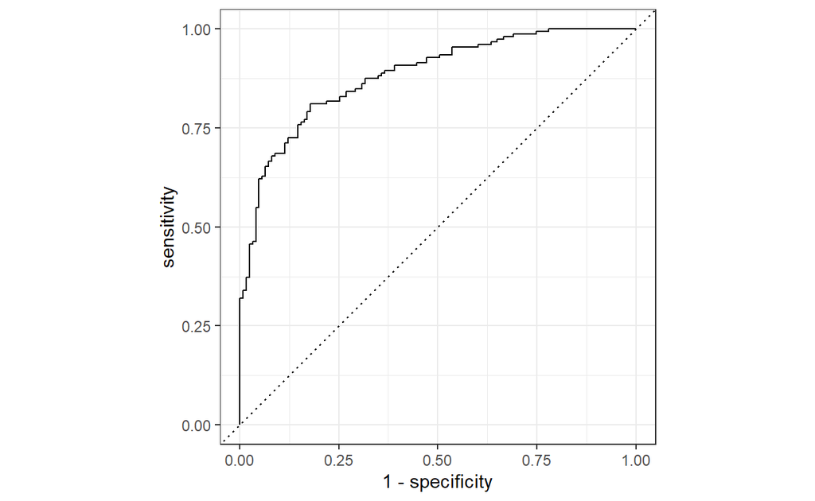

```
svm.li.pred %>%
  roc_curve(truth = HeartDisease, .pred_yes,                           # truth : 실제 클래스,  관심 클래스 예측 확률측 확률
            event_level = "second") %>%
  autoplot()
```

#### **3-7-2-2. Gain Curve**

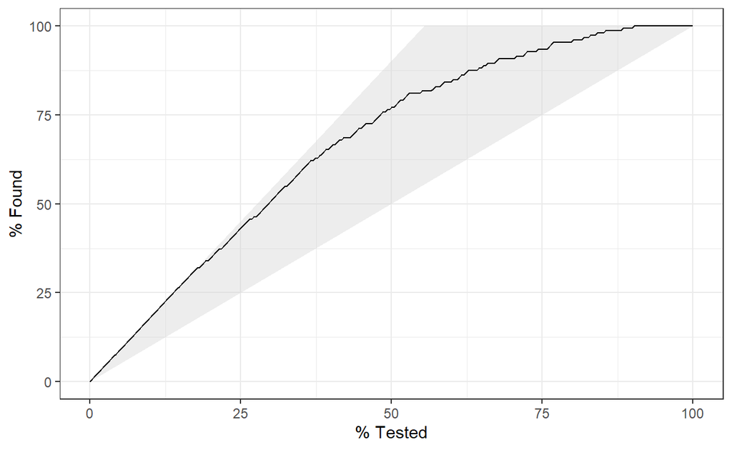

```
svm.li.pred %>%
  gain_curve(truth = HeartDisease, .pred_yes,                          # truth : 실제 클래스,  관심 클래스 예측 확률  확률
             event_level = "second") %>%
  autoplot()
```

#### **3-7-2-3. Lift Curve**

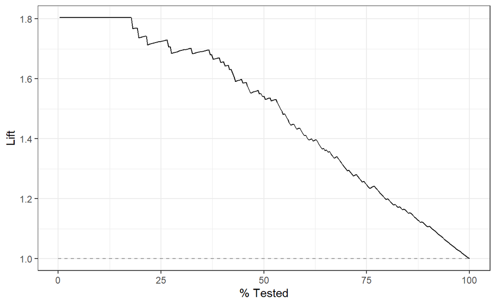

```
svm.li.pred %>%
  lift_curve(truth = HeartDisease, .pred_yes,                          # truth : 실제 클래스,  관심 클래스 예측 확률  확률
             event_level = "second") %>%
  autoplot()
```

#### **3-7-2-4. Precision Recall Curve**

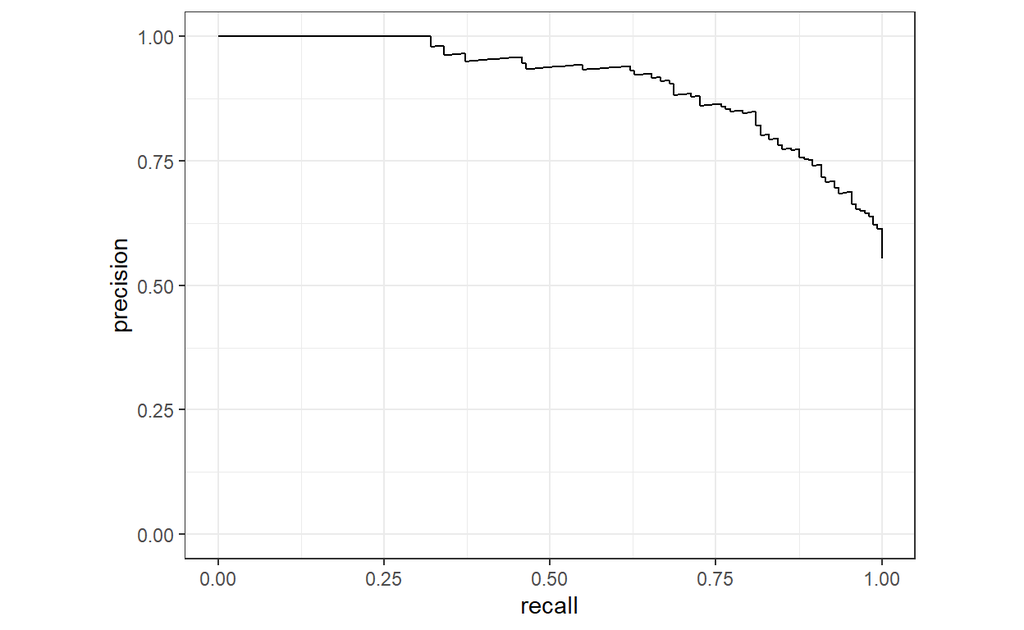

```
svm.li.pred %>%
  pr_curve(truth = HeartDisease, .pred_yes,                            # truth : 실제 클래스,  관심 클래스 예측 확률  확률
           event_level = "second") %>%
  autoplot()
```

# **4. Polynomial Kernel**

## **4-1. 전처리 정의**

- `Workflow`를 이용하기 위해 먼저 전처리를 정의한다.

```
rec  <- recipe(HeartDisease ~ ., data = HD.train) %>%                  # recipe(formula, data)
  step_normalize(all_numeric_predictors()) %>%                         # 모든 수치형 예측변수들을 표준화  step_dummy(all_nominal_predictors(), one_hot = TRUE)                 # 모든 범주형 예측변수들에 대해 원-핫 인코딩 더미변수 생성NA
```

## **4-2. 모형 정의**

- 모형을 구축하기 위해 모형을 먼저 정의한다.
  - 모형을 정의하기 위해 `모형 타입(Type)`과 `모형 종류(set_mode)` 그리고 `사용할 패키지(set_engine)`가 필요하다.
    - 모형 타입 : 사용하고자하는 머신러닝 함수 정의
      - Polynomial Kernel은 함수 `svm_poly()`를 사용한다.
    - 모형 종류 : Target 유형 정의
      - 분류(Classification) 또는 회귀(Regresssion) 중 하나를 선택한다.
    - 사용할 패키지 : 사용하고자하는 Package 정의
      - Polynomial Kernel은 Package `kernlab`를 사용할 수 있다.
- Polynomial Kernel의 모수에는 `cost`, `margin`, `degree`, `scale_factor`가 있다.
  - `cost` : 데이터를 잘못 분류하는 선을 긋게 될 경우 지불해야 할 cost
  - `margin` : SVM insensitive loss function의 epsilon (Only for Regression)
  - `degree` : Polynimial Degree
  - `scale_factor` : Polynomial Scaling Factor
- 튜닝하고 싶은 모수는 함수 `tune()`으로 지정한다.

```
svm.po.tune.mod <- svm_poly(cost         = tune(),                         # cost : 데이터를 잘못 분류하는 선을 긋게 될 경우 지불해야 할 costNA= tune(),                         # degree : Polynomial Degree
                            scale_factor = tune()) %>%                     # scale_factor : Polynomial Scaling Factor
  set_mode("classification") %>%                                           # Target 유형 정의(classification /  regression)NAset_engine("kernlab")                                                    # 사용하고자하는 패키지 정의NA# 실제 패키지에 어떻게 적용되는지 확인NAsvm.po.tune.mod %>%
  translate()
```

```
Polynomial Support Vector Machine Specification (classification)

Main Arguments:
  cost = tune()
  degree = tune()
  scale_factor = tune()

Computational engine: kernlab

Model fit template:
kernlab::ksvm(x = missing_arg(), data = missing_arg(), C = tune(),
    kernel = "polydot", prob.model = TRUE, kpar = list(degree = ~tune(),
        scale = ~tune()))
```

`Caution!` 함수 `translate()`를 통해 위에서 정의한 “svm.po.tune.mod”가 실제로 Package `kernlab`의 함수 `ksvm()`에 어떻게 적용되는지 확인할 수 있다.

## **4-3. Workflow 정의**

- 앞에서 정의한 전처리와 모형을 이용하여 `Workflow`를 정의한다.

```
svm.po.tune.wflow <- workflow() %>%                                        # Workflow 이용  add_recipe(rec) %>%                                                      # 4-1에서 정의의
  add_model(svm.po.tune.mod)                                               # 4-2에서 정의의
```

## **4-4. 모수 범위 확인**

- 함수 `extract_parameter_set_dials()`를 이용하여 모수들의 정보를 확인할 수 있다.

```
# 모수의 범위 확인NAsvm.po.param <- extract_parameter_set_dials(svm.po.tune.wflow)
svm.po.param
```

```
Collection of 3 parameters for tuning

   identifier         type    object
         cost         cost nparam[+]
       degree       degree nparam[+]
 scale_factor scale_factor nparam[+]
```

`Result!` `object`열에서 `nparam`은 모수값이 수치형임을 나타낸다. 또한, 모든 모수에 대해 `object`열이 `nparam[+]`로 해당 모수의 범위가 명확하게 주어졌음을 의미한다.

- 함수 `extract_parameter_dials()`를 이용하여 모수의 범위를 자세히 확인할 수 있다.

```
svm.po.param %>%
  extract_parameter_dials("degree")
```

```
Degree of Interaction (quantitative)
Range: [1, 3]
```

- 만약, 특정 모수의 범위를 수정하고 싶다면 함수 `update()`를 이용한다.

[output not shown]

## **4-5. 모형 적합**

### **4-5-1. Resampling 정의**

- Polynimoal Kernel의 최적의 모수 조합을 찾기 위해 Resampling 방법으로 `K-Fold Cross-Validation`을 사용한다.

```
set.seed(100)
train.fold    <- vfold_cv(HD.train, v = 5)
```

### **4-5-2. 최적의 모수 조합 찾기**

- 최적의 모수 조합을 찾기 위해 `Regular Grid`, `Latin Hypercube`, `Expand Grid`를 사용한다.

#### **4-5-2-1. Regular Grid**

```
set.seed(100)
grid <-  svm.po.param %>%
  grid_regular(levels = 2)
grid
```

```
# A tibble: 8 x 3
       cost degree scale_factor
      <dbl>  <int>        <dbl>
1  0.000977      1 0.0000000001
2 32             1 0.0000000001
3  0.000977      3 0.0000000001
4 32             3 0.0000000001
5  0.000977      1 0.1
6 32             1 0.1
7  0.000977      3 0.1
8 32             3 0.1
```

`Result!` 각 모수별로 2개씩 후보값을 두어 총 8(2 $\times$ 2 $\times$ 2)개의 후보 모수 조합을 생성하였다.

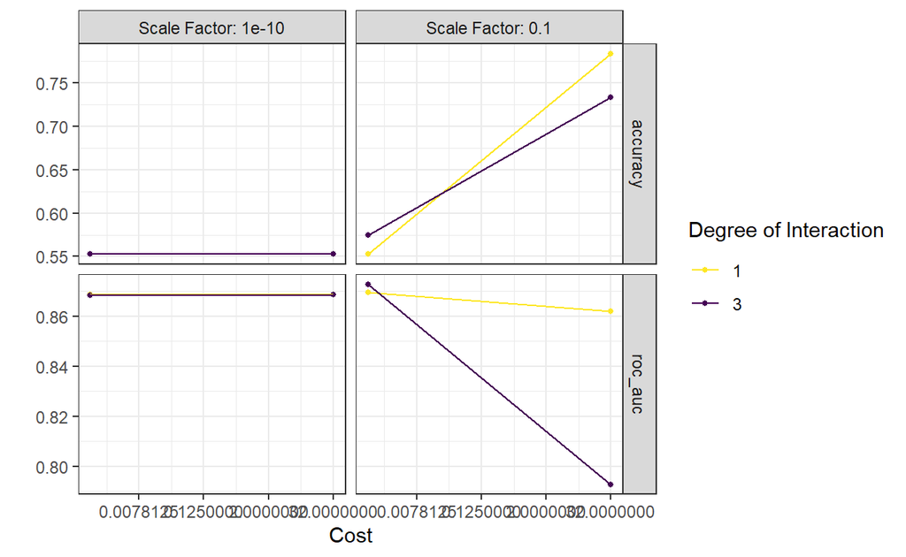

```
# 모형 적합NAset.seed(100)
svm.po.tune.grid.fit <- svm.po.tune.wflow %>%                              # 4-3에서 정의의
  tune_grid(
    train.fold,                                                            # 4-5-1에서 정의 : Resampling -> 5-Cross-Validationn
    grid = grid,                                                           # 4-5-2-1에서 정의 : 후보 모수 집합     control = control_grid(save_pred = TRUE,                               # Resampling의 Assessment 결과 저장NA= "everything"),                  # 병렬 처리(http:://tune.tidymodels.org/reference/control_grid.html) )
    metrics = metric_set(roc_auc, accuracy)                                # Assessment 그룹에 대한 Assessment Measure
  )

# 그래프
autoplot(svm.po.tune.grid.fit) +
  scale_color_viridis_d(direction = -1) +
  theme(legend.position = "top") +
  theme_bw()
```

```
# 지정된 Metric 측면에서 성능이 우수한 모형을 순서대로 확인NAshow_best(svm.po.tune.grid.fit, "roc_auc")                                 # show_best(, "accuracy")
```

```
# A tibble: 5 x 9
       cost degree scale_factor .metric .estimator  mean     n std_err
      <dbl>  <int>        <dbl> <chr>   <chr>      <dbl> <int>   <dbl>
1  0.000977      3 0.1          roc_auc binary     0.873     5  0.0115
2  0.000977      1 0.1          roc_auc binary     0.869     5  0.0122
3 32             1 0.0000000001 roc_auc binary     0.869     5  0.0114
4 32             3 0.0000000001 roc_auc binary     0.869     5  0.0114
5  0.000977      1 0.0000000001 roc_auc binary     0.869     5  0.0113
# ... with 1 more variable: .config <fct>
```

```
# 최적의 모수 조합 확인NAbest.svm.po.grid <- svm.po.tune.grid.fit %>%
  select_best("roc_auc")
best.svm.po.grid
```

```
# A tibble: 1 x 4
      cost degree scale_factor .config
     <dbl>  <int>        <dbl> <fct>
1 0.000977      3          0.1 Preprocessor1_Model7
```

`Result!` `cost = 0.000977`, `degree = 3`, `scale_factor = 0.1`일 때 “ROC AUC” 측면에서 가장 우수한 성능을 보여준다.

#### **4-5-2-2. Latin Hypercube**

```
set.seed(100)
random <- svm.po.param %>%
  grid_latin_hypercube(size = 10)
random
```

```
# A tibble: 10 x 3
       cost degree scale_factor
      <dbl>  <int>        <dbl>
 1  0.507        3     6.98e- 6
 2  8.85         1     1.89e- 3
 3  2.87         3     5.65e- 8
 4 23.2          2     3.98e- 9
 5  0.00112      2     1.47e- 2
 6  0.0163       2     2.74e- 5
 7  0.00327      1     4.63e- 7
 8  0.0456       2     4.89e-10
 9  0.136        2     4.11e- 8
10  0.235        3     4.86e- 4
```

`Result!` 10개의 후보 모수 조합을 랜덤하게 생성하였다.

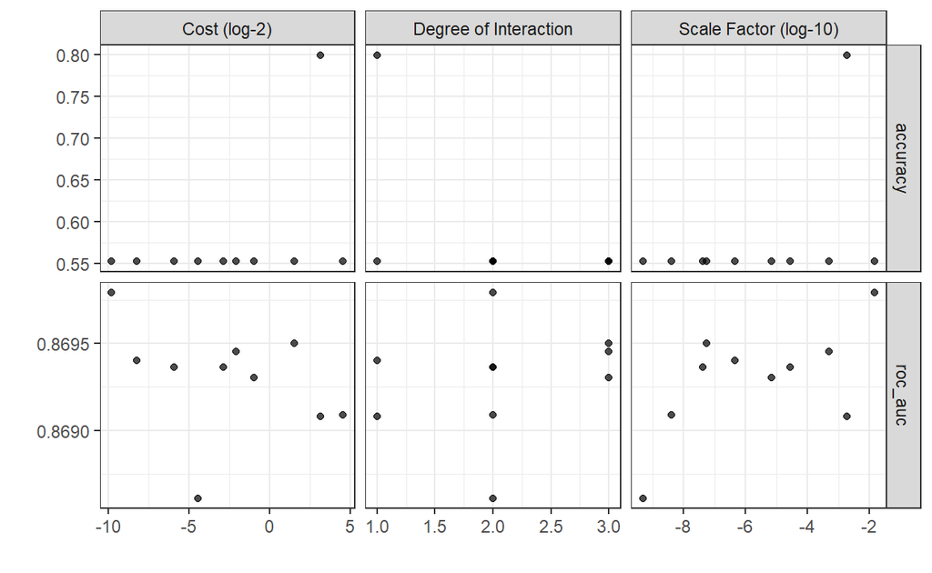

```
# 모형 적합NAset.seed(100)
svm.po.tune.random.fit <- svm.po.tune.wflow %>%                             # 4-3에서 정의의
  tune_grid(
    train.fold,                                                             # 4-5-1에서 정의 : Resampling -> 5-Cross-Validationn
    grid = random,                                                          # 4-5-2-2에서 정의 : 후보 모수 집합     control = control_grid(save_pred = TRUE,                                # Resampling의 Assessment 결과 저장NA= "everything"),                   # 병렬 처리(http:://tune.tidymodels.org/reference/control_grid.html) )
    metrics = metric_set(roc_auc, accuracy)                                 # Assessment 그룹에 대한 Assessment Measure
  )

# 그래프
autoplot(svm.po.tune.random.fit) +
  scale_color_viridis_d(direction = -1) +
  theme(legend.position = "top") +
  theme_bw()
```

```
# 지정된 Metric 측면에서 성능이 우수한 모형을 순서대로 확인NAshow_best(svm.po.tune.random.fit, "roc_auc")                                # show_best(, "accuracy")
```

```
# A tibble: 5 x 9
     cost degree scale_factor .metric .estimator  mean     n std_err
    <dbl>  <int>        <dbl> <chr>   <chr>      <dbl> <int>   <dbl>
1 0.00112      2 0.0147       roc_auc binary     0.870     5  0.0122
2 2.87         3 0.0000000565 roc_auc binary     0.870     5  0.0122
3 0.235        3 0.000486     roc_auc binary     0.869     5  0.0122
4 0.00327      1 0.000000463  roc_auc binary     0.869     5  0.0123
5 0.0163       2 0.0000274    roc_auc binary     0.869     5  0.0121
# ... with 1 more variable: .config <fct>
```

```
# 최적의 모수 조합 확인NAbest.svm.po.random <- svm.po.tune.random.fit %>%
  select_best("roc_auc")
best.svm.po.random
```

```
# A tibble: 1 x 4
     cost degree scale_factor .config
    <dbl>  <int>        <dbl> <fct>
1 0.00112      2       0.0147 Preprocessor1_Model05
```

`Result!` `cost = 0.00112`, `degree = 2`, `scale_factor = 0.0147`일 때 “ROC AUC” 측면에서 가장 우수한 성능을 보여준다.

#### **4-5-2-3. Expand Grid**

- Latin Hypercube 방법에서 최적의 모수 조합인 `cost = 0.00112`, `degree = 2`, `scale_factor = 0.0147`을 기준으로 다양한 후보값을 생성한다.

```
egrid <- expand.grid(cost         = seq(0.00112, 0.0012, 0.00001),
                     degree       = 1:3,
                     scale_factor = 0.0147)
egrid
```

```
      cost degree scale_factor
1  0.00112      1       0.0147
2  0.00113      1       0.0147
3  0.00114      1       0.0147
4  0.00115      1       0.0147
5  0.00116      1       0.0147
6  0.00117      1       0.0147
7  0.00118      1       0.0147
8  0.00119      1       0.0147
9  0.00120      1       0.0147
10 0.00112      2       0.0147
11 0.00113      2       0.0147
12 0.00114      2       0.0147
13 0.00115      2       0.0147
14 0.00116      2       0.0147
15 0.00117      2       0.0147
16 0.00118      2       0.0147
17 0.00119      2       0.0147
18 0.00120      2       0.0147
19 0.00112      3       0.0147
20 0.00113      3       0.0147
21 0.00114      3       0.0147
22 0.00115      3       0.0147
23 0.00116      3       0.0147
24 0.00117      3       0.0147
25 0.00118      3       0.0147
26 0.00119      3       0.0147
27 0.00120      3       0.0147
```

`Result!` 후보 모수값들의 집합이 생성되었다.

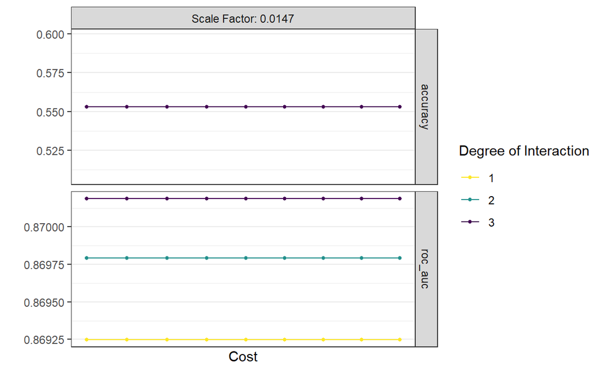

```
# 모형 적합NAset.seed(100)
svm.po.tune.egrid.fit <- svm.po.tune.wflow %>%                              # 4-3에서 정의의
  tune_grid(
    train.fold,                                                             # 4-5-1에서 정의 : Resampling -> 5-Cross-Validationn
    grid = egrid,                                                           # 4-5-2-3에서 정의 : 후보 모수 집합     control = control_grid(save_pred = TRUE,                                # Resampling의 Assessment 결과 저장NA= "everything"),                   # 병렬 처리(http:://tune.tidymodels.org/reference/control_grid.html) )
    metrics = metric_set(roc_auc, accuracy)                                 # Assessment 그룹에 대한 Assessment Measure
  )

# 그래프
autoplot(svm.po.tune.egrid.fit) +
  scale_color_viridis_d(direction = -1) +
  theme(legend.position = "top") +
  theme_bw()
```

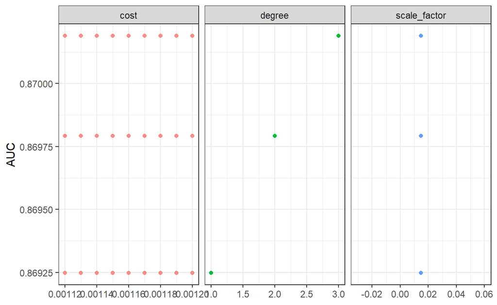

```
# Ref. https://juliasilge.com/blog/svm.pooost-tune-volleyball/
svm.po.tune.egrid.fit %>%
  collect_metrics() %>%
  filter(.metric == "roc_auc") %>%
  select(mean, cost:scale_factor) %>%
  pivot_longer(cost:scale_factor,
               values_to = "value",
               names_to = "parameter"
  ) %>%
  ggplot(aes(value, mean, color = parameter)) +
  geom_point(alpha = 0.8, show.legend = FALSE) +
  facet_wrap(~parameter, scales = "free_x") +
  labs(x = NULL, y = "AUC") +
  theme_bw()
```

```
# 지정된 Metric 측면에서 성능이 우수한 모형을 순서대로 확인NAshow_best(svm.po.tune.egrid.fit, "roc_auc")                                   # show_best(, "accuracy")
```

[output not shown]

```
# 최적의 모수 조합 확인NAbest.svm.po.egrid <- svm.po.tune.egrid.fit %>%
  select_best("roc_auc")                                                      # select_best("accuracy")
best.svm.po.egrid
```

```
# A tibble: 1 x 4
     cost degree scale_factor .config
    <dbl>  <int>        <dbl> <fct>
1 0.00112      3       0.0147 Preprocessor1_Model19
```

`Result!` `cost = 0.00112`, `degree = 3`, `scale_factor = 0.0147`일 때 “ROC AUC” 측면에서 가장 우수한 성능을 보여준다.

### **4-5-3. 최적의 모수 조합을 이용한 모형 적합**

- 최적의 모수 조합 `cost = 0.00112`, `degree = 3`, `scale_factor = 0.0147`을 이용하여 모형을 구축한다.
- 함수 `finalize_workflow()`을 이용하여 앞에서 정의한 “workflow(svm.po.tune.wflow)”를 최적의 모수 조합을 가지는 “workflow”로 업데이트한다.

```
# Workflow에 최적의 모수값 업데이트final.svm.po.wflow <- svm.po.tune.wflow %>%                                    # 4-3에서 정의의
  finalize_workflow(best.svm.po.egrid)                                         # finalize_workflow : 최적의 모수 조합을 가지는 workflow로 업데이트NAfinal.svm.po.wflow
```

```
== Workflow ==========================================================
Preprocessor: Recipe
Model: svm_poly()

-- Preprocessor ------------------------------------------------------
2 Recipe Steps

* step_normalize()
* step_dummy()

-- Model -------------------------------------------------------------
Polynomial Support Vector Machine Specification (classification)

Main Arguments:
  cost = 0.00112
  degree = 3
  scale_factor = 0.0147

Computational engine: kernlab
```

`Caution!` 함수 `last_fit()`은 최적의 모수 조합에 대해 Training Data를 이용한 모형 적합과 Test Data에 대한 예측을 한 번에 수행할 수 있지만 seed 고정이 되지 않아 Reproducibility (재생산성)가 만족되지 않는다. 따라서, 모형 적합(함수 `fit()`)과 예측(함수 `augment()`)을 각각 수행하였다.

```
# 모형 적합NAset.seed(100)
final.svm.po <- final.svm.po.wflow %>%
  fit(data = HD.train)
final.svm.po
```

```
== Workflow [trained] ================================================
Preprocessor: Recipe
Model: svm_poly()

-- Preprocessor ------------------------------------------------------
2 Recipe Steps

* step_normalize()
* step_dummy()

-- Model -------------------------------------------------------------
Support Vector Machine object of class "ksvm"

SV type: C-svc  (classification)
 parameter : cost C = 0.00112

Polynomial kernel function.
 Hyperparameters : degree =  3  scale =  0.0147  offset =  1

Number of Support Vectors : 574

Objective Function Value : -0.6346
Training error : 0.44704
Probability model included.
```

```
# 최종 모형NAfinal.svm.po %>%
  extract_fit_engine()
```

```
Support Vector Machine object of class "ksvm"

SV type: C-svc  (classification)
 parameter : cost C = 0.00112

Polynomial kernel function.
 Hyperparameters : degree =  3  scale =  0.0147  offset =  1

Number of Support Vectors : 574

Objective Function Value : -0.6346
Training error : 0.44704
Probability model included.
```

## **4-6. 예측**

```
svm.po.pred <- augment(final.svm.po, HD.test)
svm.po.pred
```

```
# A tibble: 276 x 13
     Age Sex   RestingBP Cholesterol FastingBS RestingECG MaxHR Angina
   <dbl> <fct>     <dbl>       <dbl>     <dbl> <fct>      <dbl> <fct>
 1    54 M           110         208         0 Normal       142 N
 2    37 M           140         207         0 Normal       130 Y
 3    37 F           130         211         0 Normal       142 N
 4    39 M           120         204         0 Normal       145 N
 5    49 M           140         234         0 Normal       140 Y
 6    42 F           115         211         0 ST           137 N
 7    60 M           100         248         0 Normal       125 N
 8    36 M           120         267         0 Normal       160 N
 9    43 F           100         223         0 Normal       142 N
10    36 M           130         209         0 Normal       178 N
# ... with 266 more rows, and 5 more variables:
#   HeartPeakReading <dbl>, HeartDisease <fct>, .pred_class <fct>,
#   .pred_no <dbl>, .pred_yes <dbl>
```

## **4-7. 모형 평가**

### **4-7-1. 평가 척도**

```
conf_mat(svm.po.pred, truth = HeartDisease, estimate = .pred_class)    # truth : 실제 클래스,  estimate : 예측 클래스 클래스
```

```
          Truth
Prediction  no yes
       no    0   0
       yes 123 153
```

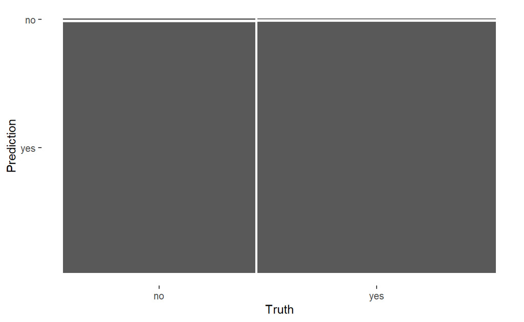

```
conf_mat(svm.po.pred, truth = HeartDisease, estimate = .pred_class) %>%
  autoplot(type = "mosaic")                                            # autoplot(type = "heatmap")
```

```
classification_metrics <- metric_set(accuracy, mcc,
                                     f_meas, kap,
                                     sens, spec, roc_auc)              # Test Data에 대한 Assessment Measure
classification_metrics(svm.po.pred, truth = HeartDisease,              # truth : 실제 클래스,  estimate : 예측 클래스 클래스
                       estimate = .pred_class,
                       .pred_yes, event_level = "second")              # For roc_auc
```

```
# A tibble: 7 x 3
  .metric  .estimator .estimate
  <chr>    <chr>          <dbl>
1 accuracy binary         0.554
2 mcc      binary        NA
3 f_meas   binary         0.713
4 kap      binary         0
5 sens     binary         1
6 spec     binary         0
7 roc_auc  binary         0.871
```

`Caution!` “ROC AUC”를 계산하기 위해서는 관심 클래스에 대한 예측 확률이 필요하다. 예제 데이터에서 관심 클래스는 “yes”이므로 “yes”에 대한 예측 확률 결과인 `.pred_yes`가 사용되었다. 또한, Target인 “HeartDisease” 변수의 유형을 “Factor” 변환하면 알파벳순으로 클래스를 부여하기 때문에 관심 클래스 “yes”가 두 번째 클래스가 된다. 따라서 옵션 `event_level = "second"`을 사용하여 관심 클래스가 “yes”임을 명시해주어야 한다.

### **4-7-2. 그래프**

`Caution!` 함수 “roc_curve(), gain_curve(), lift_curve(), pr_curve()”에서는 첫번째 클래스(Level)를 관심 클래스로 인식한다. R에서는 함수 `Factor()`를 이용하여 변수 유형을 변환하면 알파벳순(영어) 또는 오름차순(숫자)으로 클래스를 부여하므로 “HeartDisease” 변수의 경우 “no”가 첫번째 클래스가 되고 “yes”가 두번째 클래스가 된다. 따라서, 예제 데이터에서 관심 클래스는 “yes”이기 때문에 옵션 `event_level = "second"`을 사용하여 관심 클래스가 “yes”임을 명시해주어야 한다.

#### **4-7-2-1. ROC Curve**

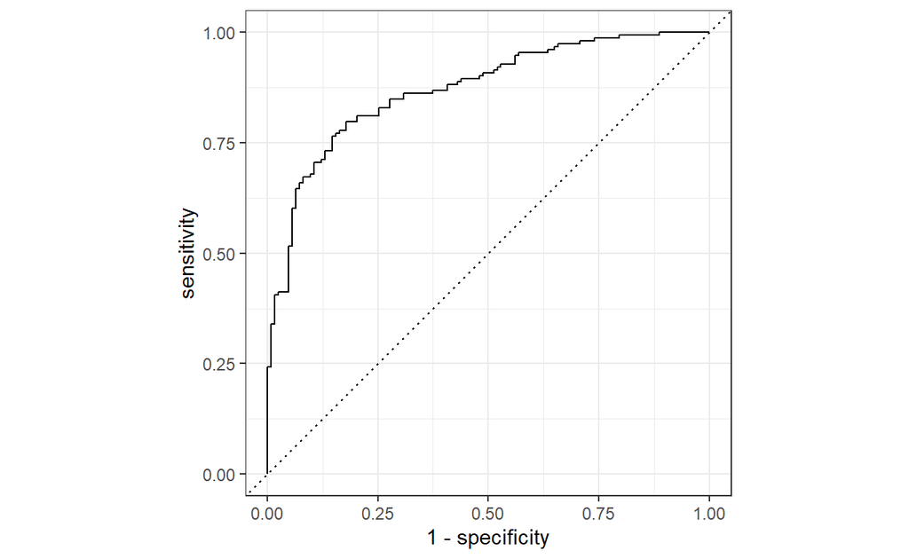

```
svm.po.pred %>%
  roc_curve(truth = HeartDisease, .pred_yes,                           # truth : 실제 클래스,  관심 클래스 예측 확률측 확률
            event_level = "second") %>%
  autoplot()
```

#### **4-7-2-2. Gain Curve**

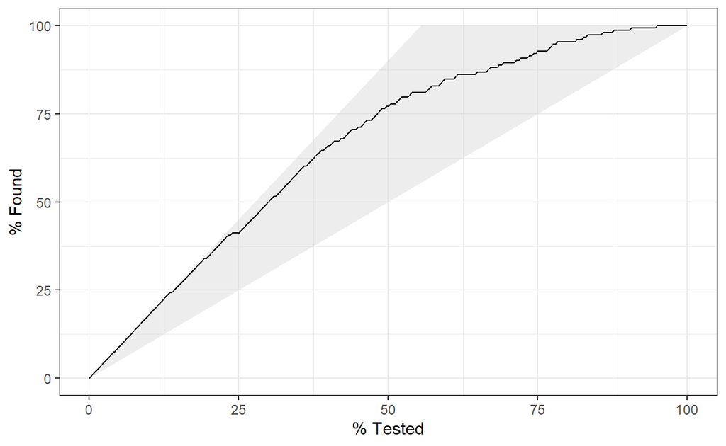

```
svm.po.pred %>%
  gain_curve(truth = HeartDisease, .pred_yes,                          # truth : 실제 클래스,  관심 클래스 예측 확률측 확률
             event_level = "second") %>%
  autoplot()
```

#### **4-7-2-3. Lift Curve**

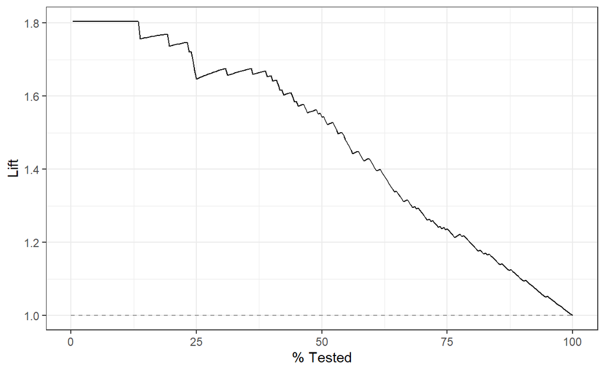

```
svm.po.pred %>%
  lift_curve(truth = HeartDisease, .pred_yes,                          # truth : 실제 클래스,  관심 클래스 예측 확률  확률
             event_level = "second") %>%
  autoplot()
```

#### **4-7-2-4. Precision Recall Curve**

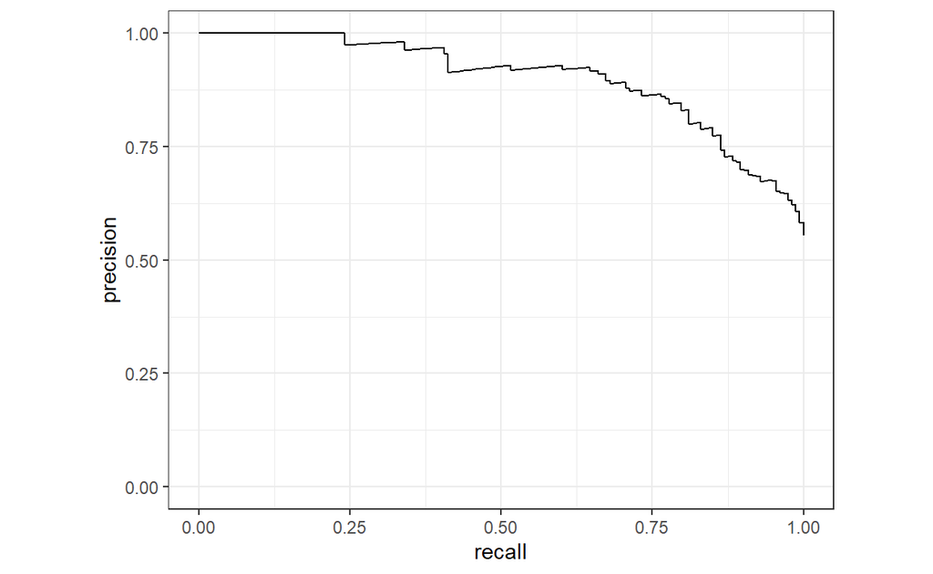

```
svm.po.pred %>%
  pr_curve(truth = HeartDisease, .pred_yes,                            # truth : 실제 클래스,  관심 클래스 예측 확률측 확률
           event_level = "second") %>%
  autoplot()
```

# **5. Radial Basis Kernel**

## **5-1. 전처리 정의**

- `Workflow`를 이용하기 위해 먼저 전처리를 정의한다.

[output not shown]

## **5-2. 모형 정의**

- 모형을 구축하기 위해 모형을 먼저 정의한다.
  - 모형을 정의하기 위해 `모형 타입(Type)`과 `모형 종류(set_mode)` 그리고 `사용할 패키지(set_engine)`가 필요하다.
    - 모형 타입 : 사용하고자하는 머신러닝 함수 정의
      - Radial Basis Kernel은 함수 `svm_rbf()`를 사용한다.
    - 모형 종류 : Target 유형 정의
      - 분류(Classification) 또는 회귀(Regresssion) 중 하나를 선택한다.
    - 사용할 패키지 : 사용하고자하는 Package 정의
      - Radial Basis Kernel은 Package `kernlab`와 `liquidSVM`를 사용할 수 있다.
- Radial Basis Kernel의 모수에는 `cost`, `margin`, `rbf_sigma`가 있다.
  - `cost` : 데이터를 잘못 분류하는 선을 긋게 될 경우 지불해야 할 cost
  - `margin` : SVM insensitive loss function의 epsilon (Only for Regression)
  - `rbf_sigma` : Precision 모수$(\gamma = \frac{1}{2\sigma^2})$
- 튜닝하고 싶은 모수는 함수 `tune()`으로 지정한다.

[output not shown]

```
Radial Basis Function Support Vector Machine Specification (classification)

Main Arguments:
  cost = tune()
  rbf_sigma = tune()

Computational engine: kernlab

Model fit template:
kernlab::ksvm(x = missing_arg(), data = missing_arg(), C = tune(),
    kernel = "rbfdot", prob.model = TRUE, kpar = list(sigma = ~tune()))
```

`Caution!` 함수 `translate()`를 통해 위에서 정의한 “svm.rbf.tune.mod”가 실제로 Package `kernlab`의 함수 `ksvm()`에 어떻게 적용되는지 확인할 수 있다.

## **5-3. Workflow 정의**

- 앞에서 정의한 전처리와 모형을 이용하여 `Workflow`를 정의한다.

```
svm.rbf.tune.wflow <- workflow() %>%                                       # Workflow 이용  add_recipe(rec) %>%                                                      # 5-1에서 정의의
  add_model(svm.rbf.tune.mod)                                              # 5-2에서 정의의
```

## **5-4. 모수 범위 확인**

- 함수 `extract_parameter_set_dials()`를 이용하여 모수들의 정보를 확인할 수 있다.

```
svm.rbf.param <- extract_parameter_set_dials(svm.rbf.tune.wflow)
svm.rbf.param
```

```
Collection of 2 parameters for tuning

 identifier      type    object
       cost      cost nparam[+]
  rbf_sigma rbf_sigma nparam[+]
```

`Result!` `object`열에서 `nparam`은 모수값이 수치형임을 나타낸다. 또한, 모든 모수에 대해 `object`열이 `nparam[+]`로 해당 모수의 범위가 명확하게 주어졌음을 의미한다.

- 함수 `extract_parameter_dials()`를 이용하여 모수의 범위를 자세히 확인할 수 있다.

```
svm.rbf.param %>%
  extract_parameter_dials("rbf_sigma")
```

```
Radial Basis Function sigma (quantitative)
Transformer:  log-10
Range (transformed scale): [-10, 0]
```

- 만약, 특정 모수의 범위를 수정하고 싶다면 함수 `update()`를 이용한다.

```
# 범위 수정
svm.rbf.param %<>%
  update(rbf_sigma =  rbf_sigma(c(1, 1000)))
```

## **5-5. 모형 적합**

### **5-5-1. Resampling 정의**

- Radial Basis Kernel의 최적의 모수 조합을 찾기 위해 Resampling 방법으로 `K-Fold Cross-Validation`을 사용한다.

```
set.seed(100)
train.fold    <- vfold_cv(HD.train, v = 5)
```

### **5-5-2. 최적의 모수 조합 찾기**

- 최적의 모수 조합을 찾기 위해 `Regular Grid`, `Latin Hypercube`, `Expand Grid`를 사용한다.

#### **5-5-2-1. Regular Grid**

```
set.seed(100)
grid <-  svm.rbf.param %>%
  grid_regular(levels = 3)
grid
```

```
# A tibble: 9 x 2
       cost    rbf_sigma
      <dbl>        <dbl>
1  0.000977 0.0000000001
2  0.177    0.0000000001
3 32        0.0000000001
4  0.000977 0.00001
5  0.177    0.00001
6 32        0.00001
7  0.000977 1
8  0.177    1
9 32        1
```

`Result!` 각 모수별로 3개씩 후보값을 두어 총 9(3 $\times$ 3)개의 후보 모수 조합을 생성하였다.

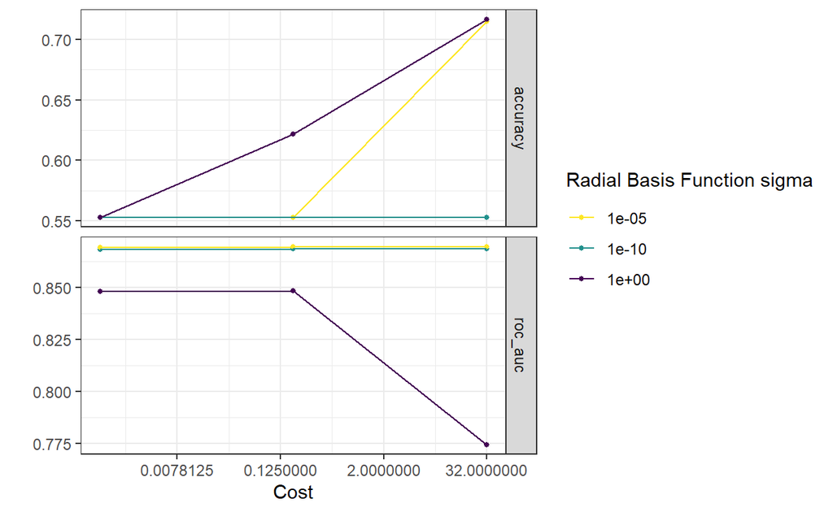

```
# 모형 적합NAset.seed(100)
svm.rbf.tune.grid.fit <- svm.rbf.tune.wflow %>%                            # 5-3에서 정의의
  tune_grid(
    train.fold,                                                            # 5-5-1에서 정의 : Resampling -> 5-Cross-Validationn
    grid = grid,                                                           # 5-5-2-1에서 정의 : 후보 모수 집합     control = control_grid(save_pred = TRUE,                               # Resampling의 Assessment 결과 저장NA= "everything"),                  # 병렬 처리(http:://tune.tidymodels.org/reference/control_grid.html) )
    metrics = metric_set(roc_auc, accuracy)                                # Assessment 그룹에 대한 Assessment Measure
  )

# 그래프
autoplot(svm.rbf.tune.grid.fit) +
  scale_color_viridis_d(direction = -1) +
  theme(legend.position = "top") +
  theme_bw()
```

```
# 지정된 Metric 측면에서 성능이 우수한 모형을 순서대로 확인NAshow_best(svm.rbf.tune.grid.fit, "roc_auc")                                 # show_best(, "accuracy")
```

```
# A tibble: 5 x 8
       cost   rbf_sigma .metric .estimator  mean     n std_err .config
      <dbl>       <dbl> <chr>   <chr>      <dbl> <int>   <dbl> <fct>
1  0.177          1e- 5 roc_auc binary     0.870     5  0.0124 Prepro~
2 32              1e- 5 roc_auc binary     0.870     5  0.0122 Prepro~
3  0.000977       1e- 5 roc_auc binary     0.870     5  0.0122 Prepro~
4  0.177          1e-10 roc_auc binary     0.869     5  0.0113 Prepro~
5 32              1e-10 roc_auc binary     0.869     5  0.0114 Prepro~
```

```
# 최적의 모수 조합 확인NAbest.svm.rbf.grid <- svm.rbf.tune.grid.fit %>%
  select_best("roc_auc")
best.svm.rbf.grid
```

```
# A tibble: 1 x 3
   cost rbf_sigma .config
  <dbl>     <dbl> <fct>
1 0.177   0.00001 Preprocessor1_Model5
```

`Result!` `cost = 0.177`, `rbf_sigma = 0.00001`일 때 “ROC AUC” 측면에서 가장 우수한 성능을 보여준다.

#### **5-5-2-2. Latin Hypercube**

```
set.seed(100)
random <- svm.rbf.param %>%
  grid_latin_hypercube(size = 10)
random
```

```
# A tibble: 10 x 2
       cost rbf_sigma
      <dbl>     <dbl>
 1  0.0633   6.47e- 4
 2  0.0173   9.00e- 2
 3  0.358    1.12e- 5
 4  0.00200  7.21e- 8
 5  0.573    4.59e- 9
 6  2.95     4.60e- 3
 7  0.00327  2.53e- 7
 8  8.25     5.62e-10
 9 24.6      2.57e- 1
10  0.0293   4.86e- 6
```

`Result!` 10개의 후보 모수 조합을 랜덤하게 생성하였다.

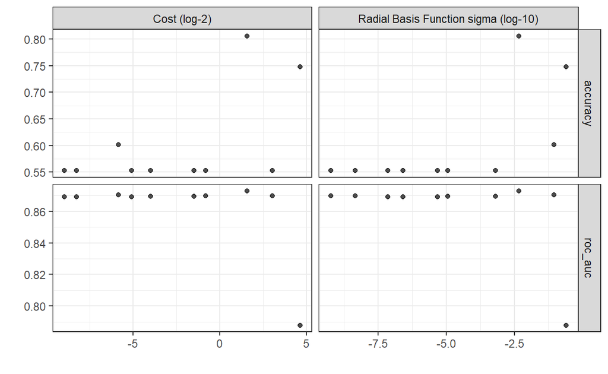

```
# 모형 적합NAset.seed(100)
svm.rbf.tune.random.fit <- svm.rbf.tune.wflow %>%                           # 5-3에서 정의의
  tune_grid(
    train.fold,                                                             # 5-5-1에서 정의 : Resampling -> 5-Cross-Validationn
    grid = random,                                                          # 5-5-2-2에서 정의 : 후보 모수 집합     control = control_grid(save_pred = TRUE,                                # Resampling의 Assessment 결과 저장NA= "everything"),                   # 병렬 처리(http:://tune.tidymodels.org/reference/control_grid.html) )
    metrics = metric_set(roc_auc, accuracy)                                 # Assessment 그룹에 대한 Assessment Measure
  )

# 그래프
autoplot(svm.rbf.tune.random.fit) +
  scale_color_viridis_d(direction = -1) +
  theme(legend.position = "top") +
  theme_bw()
```

```
# 지정된 Metric 측면에서 성능이 우수한 모형을 순서대로 확인NAshow_best(svm.rbf.tune.random.fit, "roc_auc")                                # show_best(, "accuracy")
```

```
# A tibble: 5 x 8
    cost rbf_sigma .metric .estimator  mean     n std_err .config
   <dbl>     <dbl> <chr>   <chr>      <dbl> <int>   <dbl> <fct>
1 2.95    4.60e- 3 roc_auc binary     0.873     5 0.0112  Preprocesso~
2 0.0173  9.00e- 2 roc_auc binary     0.870     5 0.00849 Preprocesso~
3 8.25    5.62e-10 roc_auc binary     0.870     5 0.0114  Preprocesso~
4 0.573   4.59e- 9 roc_auc binary     0.870     5 0.0120  Preprocesso~
5 0.0633  6.47e- 4 roc_auc binary     0.870     5 0.0122  Preprocesso~
```

```
# 최적의 모수 조합 확인NAbest.svm.rbf.random <- svm.rbf.tune.random.fit %>%
  select_best("roc_auc")
best.svm.rbf.random
```

```
# A tibble: 1 x 3
   cost rbf_sigma .config
  <dbl>     <dbl> <fct>
1  2.95   0.00460 Preprocessor1_Model06
```

`Result!` `cost = 2.95`, `rbf_sigma = 0.00460`일 때 “ROC AUC” 측면에서 가장 우수한 성능을 보여준다.

#### **5-5-2-3. Expand Grid**

- Latin Hypercube 방법에서 최적의 모수 조합인 `cost = 2.95`, `rbf_sigma = 0.00460`을 기준으로 다양한 후보값을 생성한다.

```
egrid <- expand.grid(cost      = seq(2.94, 2.95, 0.001),
                     rbf_sigma = seq(0.0046, 0.0047, 0.0001))
egrid
```

```
    cost rbf_sigma
1  2.940    0.0046
2  2.941    0.0046
3  2.942    0.0046
4  2.943    0.0046
5  2.944    0.0046
6  2.945    0.0046
7  2.946    0.0046
8  2.947    0.0046
9  2.948    0.0046
10 2.949    0.0046
11 2.950    0.0046
12 2.940    0.0047
13 2.941    0.0047
14 2.942    0.0047
15 2.943    0.0047
16 2.944    0.0047
17 2.945    0.0047
18 2.946    0.0047
19 2.947    0.0047
20 2.948    0.0047
21 2.949    0.0047
22 2.950    0.0047
```

`Result!` 후보 모수값들의 집합이 생성되었다.

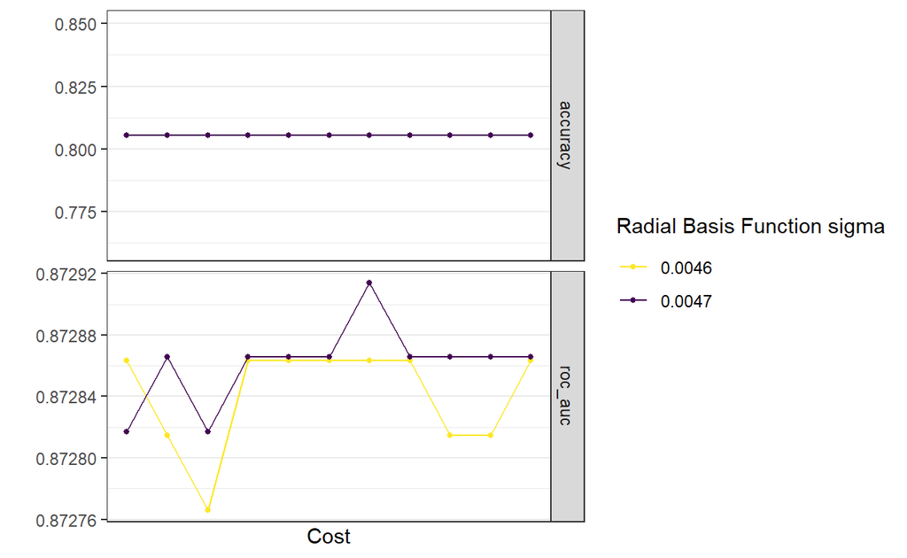

```
set.seed(100)
svm.rbf.tune.egrid.fit <- svm.rbf.tune.wflow %>%                            # 5-3에서 정의의
  tune_grid(
    train.fold,                                                             # 5-5-1에서 정의 : Resampling -> 5-Cross-Validationn
    grid = egrid,                                                           # 5-5-2-3에서 정의 : 후보 모수 집합     control = control_grid(save_pred = TRUE,                                # Resampling의 Assessment 결과 저장NA= "everything"),                   # 병렬 처리(http:://tune.tidymodels.org/reference/control_grid.html) )
    metrics = metric_set(roc_auc, accuracy)                                 # Assessment 그룹에 대한 Assessment Measure
  )

# 그래프
autoplot(svm.rbf.tune.egrid.fit) +
  scale_color_viridis_d(direction = -1) +
  theme(legend.position = "top") +
  theme_bw()
```

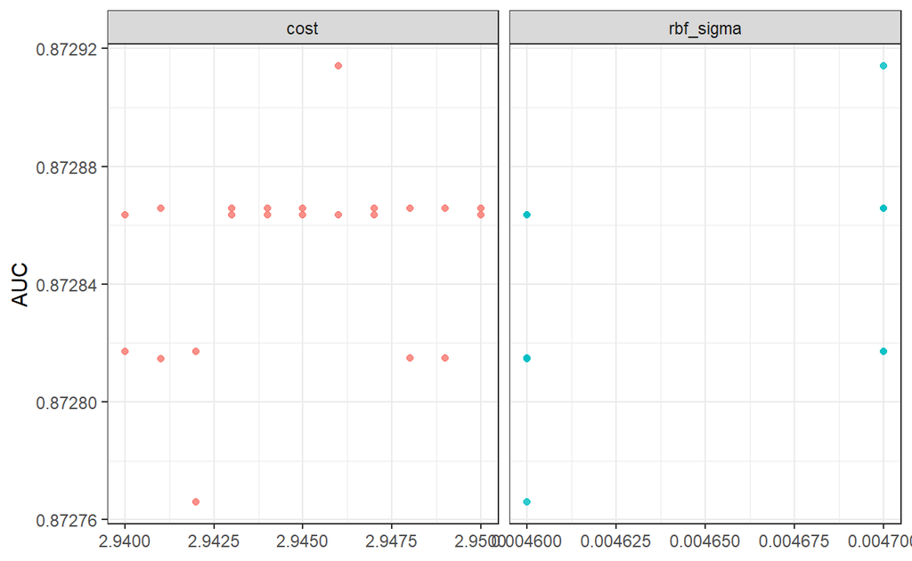

```
# Ref. https://juliasilge.com/blog/svm.rbfoost-tune-volleyball/
svm.rbf.tune.egrid.fit %>%
  collect_metrics() %>%
  filter(.metric == "roc_auc") %>%
  select(mean, cost:rbf_sigma) %>%
  pivot_longer(cost:rbf_sigma,
               values_to = "value",
               names_to = "parameter"
  ) %>%
  ggplot(aes(value, mean, color = parameter)) +
  geom_point(alpha = 0.8, show.legend = FALSE) +
  facet_wrap(~parameter, scales = "free_x") +
  labs(x = NULL, y = "AUC") +
  theme_bw()
```

```
# 지정된 Metric 측면에서 성능이 우수한 모형을 순서대로 확인NAshow_best(svm.rbf.tune.egrid.fit, "roc_auc")                                # show_best(, "accuracy")
```

```
# A tibble: 5 x 8
   cost rbf_sigma .metric .estimator  mean     n std_err .config
  <dbl>     <dbl> <chr>   <chr>      <dbl> <int>   <dbl> <fct>
1  2.95    0.0047 roc_auc binary     0.873     5  0.0112 Preprocessor~
2  2.94    0.0047 roc_auc binary     0.873     5  0.0112 Preprocessor~
3  2.94    0.0047 roc_auc binary     0.873     5  0.0112 Preprocessor~
4  2.94    0.0047 roc_auc binary     0.873     5  0.0112 Preprocessor~
5  2.94    0.0047 roc_auc binary     0.873     5  0.0112 Preprocessor~
```

```
# 최적의 모수 조합 확인NAbest.svm.rbf.egrid <- svm.rbf.tune.egrid.fit %>%
  select_best("roc_auc")                                                    # select_best("accuracy")
best.svm.rbf.egrid
```

```
# A tibble: 1 x 3
   cost rbf_sigma .config
  <dbl>     <dbl> <fct>
1  2.95    0.0047 Preprocessor1_Model18
```

`Result!` `cost = 2.946`, `rbf_sigma = 0.0047`일 때 “ROC AUC” 측면에서 가장 우수한 성능을 보여준다.

### **5-5-3. 최적의 모수 조합을 이용한 모형 적합**

- 최적의 모수 조합 `cost = 2.946`, `rbf_sigma = 0.0047`을 이용하여 모형을 구축한다.
- 함수 `finalize_workflow()`을 이용하여 앞에서 정의한 “workflow(svm.rbf.tune.wflow)”를 최적의 모수 조합을 가지는 “workflow”로 업데이트한다.

```
# Workflow에 최적의 모수값 업데이트final.svm.rbf.wflow <- svm.rbf.tune.wflow %>%                               # 5-3에서 정의의
  finalize_workflow(best.svm.rbf.egrid)                                     # finalize_workflow : 최적의 모수 조합을 가지는 workflow로 업데이트NAfinal.svm.rbf.wflow
```

```
== Workflow ==========================================================
Preprocessor: Recipe
Model: svm_rbf()

-- Preprocessor ------------------------------------------------------
2 Recipe Steps

* step_normalize()
* step_dummy()

-- Model -------------------------------------------------------------
Radial Basis Function Support Vector Machine Specification (classification)

Main Arguments:
  cost = 2.946
  rbf_sigma = 0.0047

Computational engine: kernlab
```

`Caution!` 함수 `last_fit()`은 최적의 모수 조합에 대해 Training Data를 이용한 모형 적합과 Test Data에 대한 예측을 한 번에 수행할 수 있지만 seed 고정이 되지 않아 Reproducibility (재생산성)가 만족되지 않는다. 따라서, 모형 적합(함수 `fit()`)과 예측(함수 `augment()`)을 각각 수행하였다.

```
# 모형 적합NAset.seed(100)
final.svm.rbf <- final.svm.rbf.wflow %>%
  fit(data = HD.train)
final.svm.rbf
```

```
== Workflow [trained] ================================================
Preprocessor: Recipe
Model: svm_rbf()

-- Preprocessor ------------------------------------------------------
2 Recipe Steps

* step_normalize()
* step_dummy()

-- Model -------------------------------------------------------------
Support Vector Machine object of class "ksvm"

SV type: C-svc  (classification)
 parameter : cost C = 2.946

Gaussian Radial Basis kernel function.
 Hyperparameter : sigma =  0.0047

Number of Support Vectors : 320

Objective Function Value : -871.6852
Training error : 0.193146
Probability model included.
```

```
# 최종 모형NAfinal.svm.rbf %>%
  extract_fit_engine()
```

```
Support Vector Machine object of class "ksvm"

SV type: C-svc  (classification)
 parameter : cost C = 2.946

Gaussian Radial Basis kernel function.
 Hyperparameter : sigma =  0.0047

Number of Support Vectors : 320

Objective Function Value : -871.6852
Training error : 0.193146
Probability model included.
```

## **5-6. 예측**

```
svm.rbf.pred <- augment(final.svm.rbf, HD.test)
svm.rbf.pred
```

```
# A tibble: 276 x 13
     Age Sex   RestingBP Cholesterol FastingBS RestingECG MaxHR Angina
   <dbl> <fct>     <dbl>       <dbl>     <dbl> <fct>      <dbl> <fct>
 1    54 M           110         208         0 Normal       142 N
 2    37 M           140         207         0 Normal       130 Y
 3    37 F           130         211         0 Normal       142 N
 4    39 M           120         204         0 Normal       145 N
 5    49 M           140         234         0 Normal       140 Y
 6    42 F           115         211         0 ST           137 N
 7    60 M           100         248         0 Normal       125 N
 8    36 M           120         267         0 Normal       160 N
 9    43 F           100         223         0 Normal       142 N
10    36 M           130         209         0 Normal       178 N
# ... with 266 more rows, and 5 more variables:
#   HeartPeakReading <dbl>, HeartDisease <fct>, .pred_class <fct>,
#   .pred_no <dbl>, .pred_yes <dbl>
```

## **5-7. 모형 평가**

### **5-7-1. 평가 척도**

```
conf_mat(svm.rbf.pred, truth = HeartDisease, estimate = .pred_class)   # truth : 실제 클래스,  estimate : 예측 클래스 클래스
```

```
          Truth
Prediction  no yes
       no   94  34
       yes  29 119
```

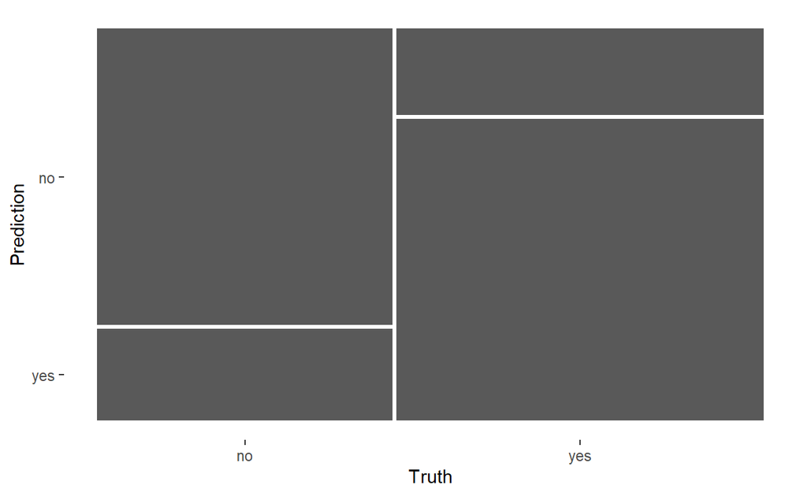

```
conf_mat(svm.rbf.pred, truth = HeartDisease, estimate = .pred_class) %>%
  autoplot(type = "mosaic")                                            # autoplot(type = "heatmap")
```

```
classification_metrics <- metric_set(accuracy, mcc,
                                     f_meas, kap,
                                     sens, spec, roc_auc)              # Test Data에 대한 Assessment Measure
classification_metrics(svm.rbf.pred, truth = HeartDisease,             # truth : 실제 클래스,  estimate : 예측 클래스 클래스
                       estimate = .pred_class,
                       .pred_yes, event_level = "second")              # For roc_auc
```

```
# A tibble: 7 x 3
  .metric  .estimator .estimate
  <chr>    <chr>          <dbl>
1 accuracy binary         0.772
2 mcc      binary         0.540
3 f_meas   binary         0.791
4 kap      binary         0.540
5 sens     binary         0.778
6 spec     binary         0.764
7 roc_auc  binary         0.884
```

`Caution!` “ROC AUC”를 계산하기 위해서는 관심 클래스에 대한 예측 확률이 필요하다. 예제 데이터에서 관심 클래스는 “yes”이므로 “yes”에 대한 예측 확률 결과인 `.pred_yes`가 사용되었다. 또한, Target인 “HeartDisease” 변수의 유형을 “Factor” 변환하면 알파벳순으로 클래스를 부여하기 때문에 관심 클래스 “yes”가 두 번째 클래스가 된다. 따라서 옵션 `event_level = "second"`을 사용하여 관심 클래스가 “yes”임을 명시해주어야 한다.

### **5-7-2. 그래프**

`Caution!` 함수 “roc_curve(), gain_curve(), lift_curve(), pr_curve()”에서는 첫번째 클래스(Level)를 관심 클래스로 인식한다. R에서는 함수 `Factor()`를 이용하여 변수 유형을 변환하면 알파벳순(영어) 또는 오름차순(숫자)으로 클래스를 부여하므로 “HeartDisease” 변수의 경우 “no”가 첫번째 클래스가 되고 “yes”가 두번째 클래스가 된다. 따라서, 예제 데이터에서 관심 클래스는 “yes”이기 때문에 옵션 `event_level = "second"`을 사용하여 관심 클래스가 “yes”임을 명시해주어야 한다.

#### **5-7-2-1. ROC Curve**

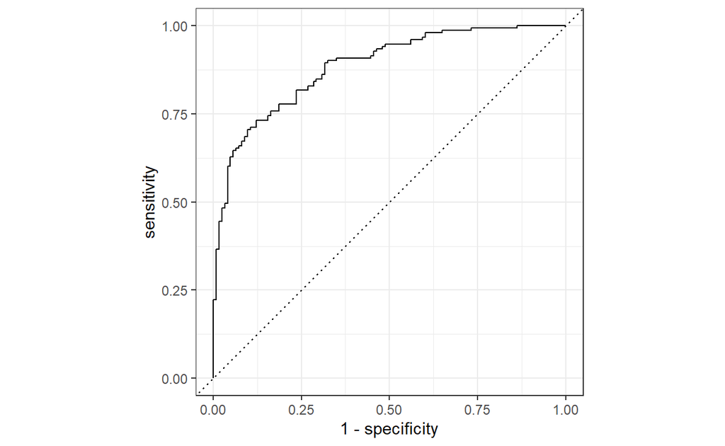

```
svm.rbf.pred %>%
  roc_curve(truth = HeartDisease, .pred_yes,                           # truth : 실제 클래스,  관심 클래스 예측 확률측 확률
            event_level = "second") %>%
  autoplot()
```

#### **5-7-2-2. Gain Curve**

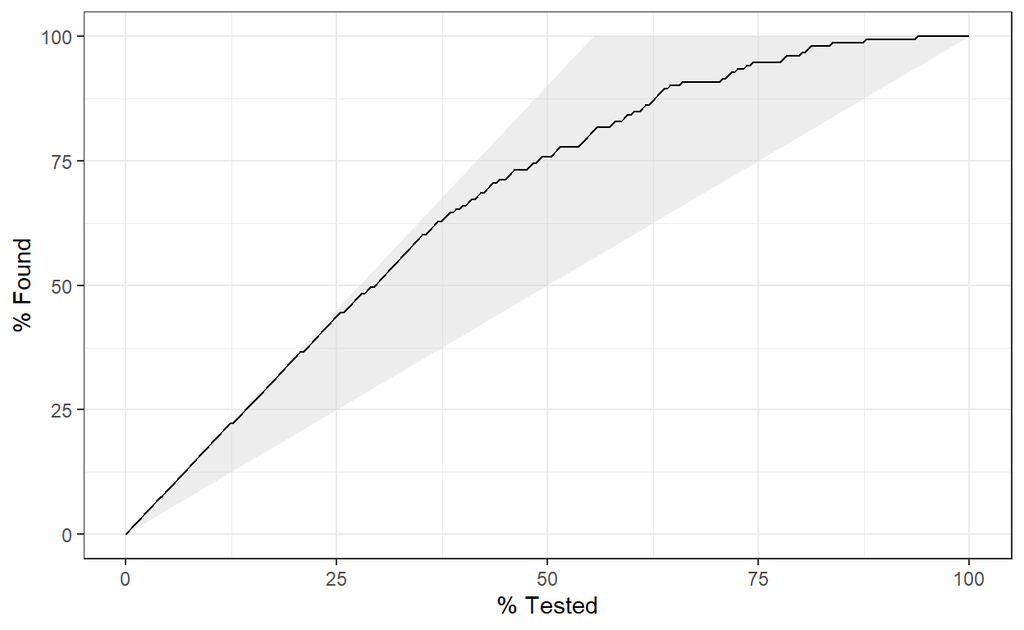

```
svm.rbf.pred %>%
  gain_curve(truth = HeartDisease, .pred_yes,                          # truth : 실제 클래스,  관심 클래스 예측 확률  확률
             event_level = "second") %>%
  autoplot()
```

#### **5-7-2-3. Lift Curve**

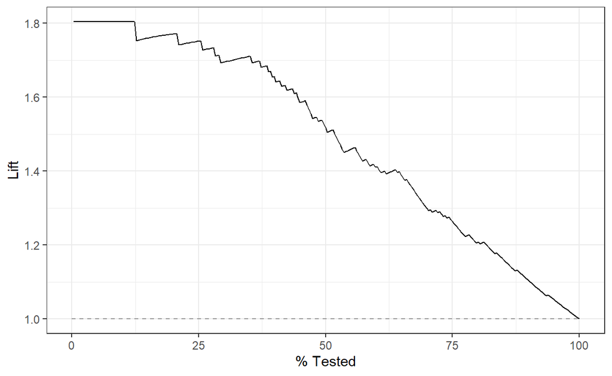

```
svm.rbf.pred %>%
  lift_curve(truth = HeartDisease, .pred_yes,                          # truth : 실제 클래스,  관심 클래스 예측 확률  확률
             event_level = "second") %>%
  autoplot()
```

#### **5-7-2-4. Precision Recall Curve**

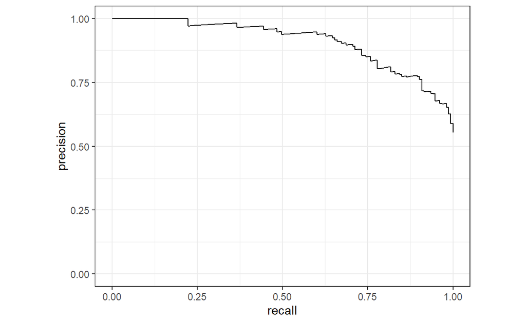

```
svm.rbf.pred %>%
  pr_curve(truth = HeartDisease, .pred_yes,                            # truth : 실제 클래스,  관심 클래스 예측 확률  확률
           event_level = "second") %>%
  autoplot()
```